# Clustering - Final version for conference

Antal Ertl

2023-04-04

### Defining the number of Principal Components to look at

Using the demeaned data, the factor choice is no longer clear at factor = 4 but it is good enough

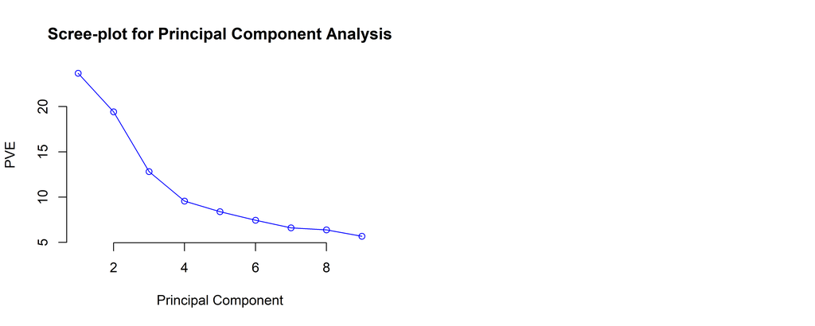

Alternatively, look at the number of Principal Components to attaint using Parallel Analysis.

Parallel Analysis: specify how many components to retain using simulation

Here, we get the critical values for each component. If the eigenvalues from the PCA are greater than the value at 0.95 confint, we can retain given component.

[output not shown]

```
## Principal Components Analysis
## Call: psych::principal(r = ., nfactors = 4, rotate = "varimax")
## Standardized loadings (pattern matrix) based upon correlation matrix
##                            RC2   RC1   RC4   RC3   h2   u2 com
## delta_diff               -0.79  0.04  0.06  0.06 0.63 0.37 1.0
## beta_diff                 0.74  0.07 -0.01 -0.14 0.57 0.43 1.1
## beta_0_diff               0.75 -0.11  0.09  0.11 0.60 0.40 1.1
## dictator_diff             0.00  0.16  0.83 -0.05 0.72 0.28 1.1
## dictator_schoolmate_diff  0.01  0.12  0.84 -0.02 0.72 0.28 1.0
## risk_diff                -0.07  0.08 -0.06  0.94 0.89 0.11 1.0
## publicgood_diff          -0.01  0.78 -0.03  0.11 0.62 0.38 1.0
## trust_diff               -0.06  0.66  0.29  0.29 0.61 0.39 1.8
## trust_return_diff        -0.04  0.67  0.21 -0.21 0.54 0.46 1.4
##
##                        RC2  RC1  RC4  RC3
## SS loadings           1.74 1.56 1.54 1.05
## Proportion Var        0.19 0.17 0.17 0.12
## Cumulative Var        0.19 0.37 0.54 0.65
## Proportion Explained  0.29 0.26 0.26 0.18
## Cumulative Proportion 0.29 0.56 0.82 1.00
##
## Mean item complexity =  1.2
## Test of the hypothesis that 4 components are sufficient.
##
## The root mean square of the residuals (RMSR) is  0.11
##  with the empirical chi square  846.58  with prob <  1.3e-179
##
## Fit based upon off diagonal values = 0.7
```

Overall, no clear indication on the number of components; still, in order to make it comparable with the non-demeaned data, I calculate with 4 factors in the PCA.

### 3 Factor PCA

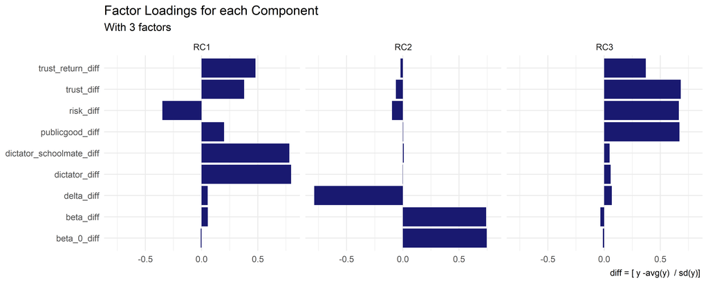

#### 4 Factor PCA

```
##
## Loadings:
##                          RC2    RC1    RC4    RC3
## delta_diff               -0.786
## beta_diff                 0.737               -0.140
## beta_0_diff               0.752 -0.109         0.113
## dictator_diff                    0.158  0.831
## dictator_schoolmate_diff         0.121  0.840
## risk_diff                                      0.937
## publicgood_diff                  0.779         0.111
## trust_diff                       0.665  0.290  0.287
## trust_return_diff                0.669  0.207 -0.210
##
##                  RC2   RC1   RC4   RC3
## SS loadings    1.738 1.561 1.540 1.055
## Proportion Var 0.193 0.173 0.171 0.117
## Cumulative Var 0.193 0.367 0.538 0.655
```

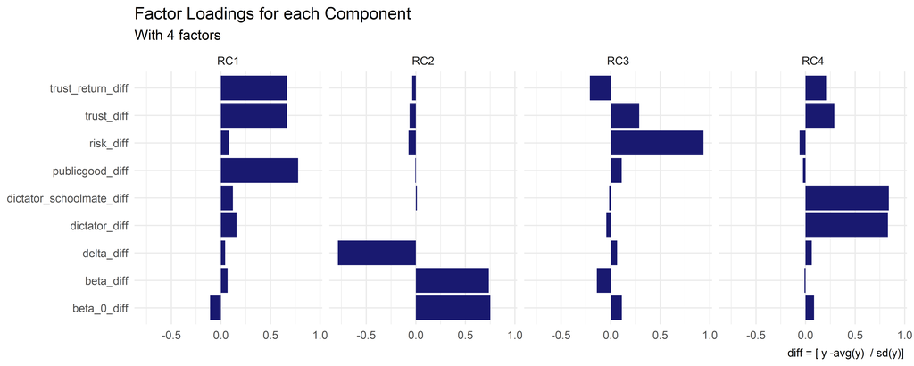

Bottom line: demeaned megmaradtak ugyanazok az eredmények.

A továbbiakban a 4 faktoros PCA-val számoltam. Az elemek elnevezései a következők:

- RC1.: interakciót igénylő társas preferenciák
- RC2: időpreferencia
- RC4: Interakciót nem igénylő társas preferenciák
- RC3: kockázati preferencia

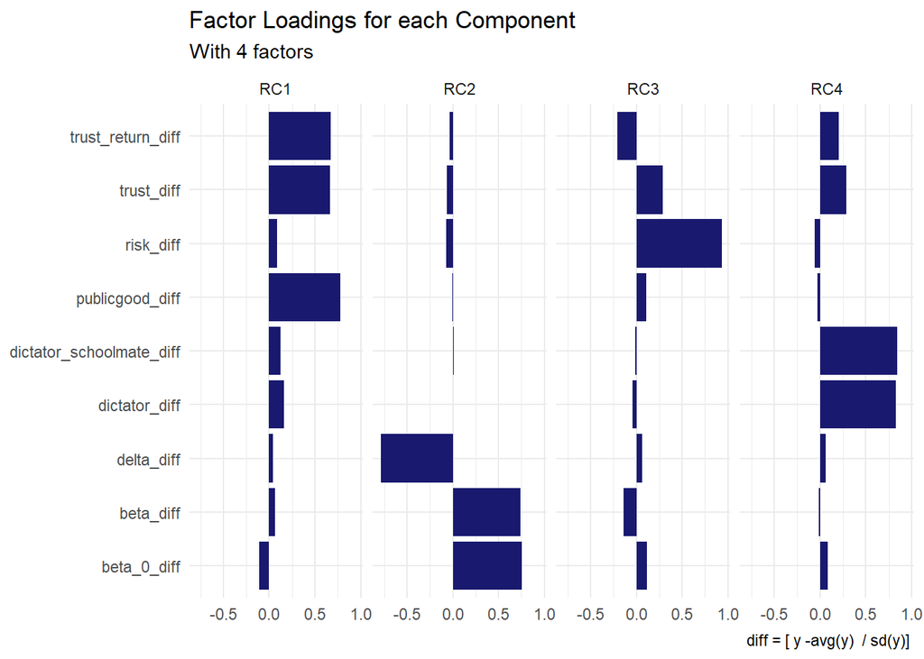

## Random Forest

Az ÖSSZES további Random Forest illesztésben a “math” változóra illesztettem a fákat. Lehet még olyat is illeszteni, ahol pl. top 15% percentilisre lövünk.

Random forest math változóra; PCA változók nélkül

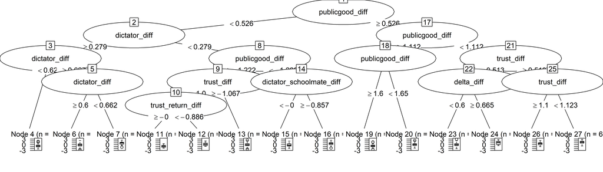

Összehasonlítás a nyers változókkal:

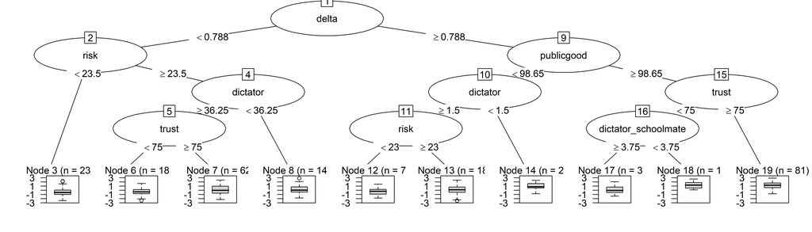

## Sima lineáris regresszió - PCA-kkal

```
##
## Call:
## lm(formula = math ~ pca_socpref_interact + pca_timepref + pca_socpref_nointeract +
##     pca_riskpref + comp + age + read, data = data_analysis_clean)
##
## Residuals:
##      Min       1Q   Median       3Q      Max
## -1.99211 -0.47788 -0.02238  0.44725  1.82751
##
## Coefficients:
##                         Estimate Std. Error t value Pr(>|t|)
## (Intercept)             0.845618   0.310207   2.726  0.00652 **
## pca_socpref_interact    0.026770   0.020555   1.302  0.19309
## pca_timepref           -0.055371   0.020567  -2.692  0.00721 **
## pca_socpref_nointeract  0.007314   0.020801   0.352  0.72520
## pca_riskpref           -0.029846   0.020631  -1.447  0.14830
## comp                   -0.011210   0.042792  -0.262  0.79341
## age                    -0.004166   0.001533  -2.718  0.00668 **
## read                    0.733748   0.020831  35.224  < 2e-16 ***
## ---
## Signif. codes:  0 '***' 0.001 '**' 0.01 '*' 0.05 '.' 0.1 ' ' 1
##
## Residual standard error: 0.6595 on 1027 degrees of freedom
## Multiple R-squared:  0.5677, Adjusted R-squared:  0.5647
## F-statistic: 192.6 on 7 and 1027 DF,  p-value: < 2.2e-16
```

A két regresszió közti R-négyzet különbség is nagyon durva.

```
##
## Call:
## lm(formula = math ~ pca_socpref_interact + pca_timepref + pca_socpref_nointeract +
##     pca_riskpref + comp, data = data_analysis_clean)
##
## Residuals:
##     Min      1Q  Median      3Q     Max
## -2.5280 -0.6660 -0.1087  0.6419  3.0164
##
## Coefficients:
##                        Estimate Std. Error t value Pr(>|t|)
## (Intercept)             0.06214    0.05011   1.240  0.21520
## pca_socpref_interact    0.07222    0.03083   2.343  0.01934 *
## pca_timepref           -0.09162    0.03088  -2.967  0.00308 **
## pca_socpref_nointeract  0.07472    0.03114   2.400  0.01659 *
## pca_riskpref           -0.03011    0.03101  -0.971  0.33189
## comp                   -0.10043    0.06413  -1.566  0.11764
## ---
## Signif. codes:  0 '***' 0.001 '**' 0.01 '*' 0.05 '.' 0.1 ' ' 1
##
## Residual standard error: 0.9914 on 1029 degrees of freedom
## Multiple R-squared:  0.02112,    Adjusted R-squared:  0.01636
## F-statistic: 4.439 on 5 and 1029 DF,  p-value: 0.0005251
```

diff adatokra illesztve:

```
##
## Call:
## lm(formula = math ~ delta_diff + beta_diff + dictator_diff +
##     dictator_schoolmate_diff + risk_diff + publicgood_diff +
##     trust_diff + trust_return_diff + age + read, data = data_analysis_clean)
##
## Residuals:
##      Min       1Q   Median       3Q      Max
## -2.07376 -0.46801 -0.03579  0.42804  1.83816
##
## Coefficients:
##                           Estimate Std. Error t value Pr(>|t|)
## (Intercept)               0.822045   0.308671   2.663 0.007862 **
## delta_diff                0.081360   0.022886   3.555 0.000395 ***
## beta_diff                 0.016274   0.022705   0.717 0.473699
## dictator_diff            -0.074495   0.024505  -3.040 0.002426 **
## dictator_schoolmate_diff  0.026741   0.024314   1.100 0.271672
## risk_diff                -0.002134   0.021654  -0.099 0.921512
## publicgood_diff           0.020475   0.022676   0.903 0.366771
## trust_diff                0.013263   0.024353   0.545 0.586141
## trust_return_diff         0.009740   0.022751   0.428 0.668661
## age                      -0.004085   0.001523  -2.681 0.007450 **
## read                      0.737694   0.020746  35.558  < 2e-16 ***
## ---
## Signif. codes:  0 '***' 0.001 '**' 0.01 '*' 0.05 '.' 0.1 ' ' 1
##
## Residual standard error: 0.6563 on 1024 degrees of freedom
## Multiple R-squared:  0.573,  Adjusted R-squared:  0.5688
## F-statistic: 137.4 on 10 and 1024 DF,  p-value: < 2.2e-16
```

## Klasszifikáció a legjobb 20% matekosra

Ha a legjobb 20% matekosra futtatok klasszifikációt, akkor a legfontosabbak a klasszifikáció szempontjából a következők:

- trust
- delta
- trust_return
- fontos még a dictator_schoolmate (de csak 33 eset klasszifikációjában ebben a futtatásban)

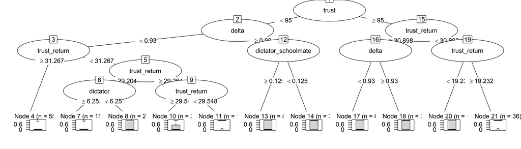

Random Forest PCA-kkal:

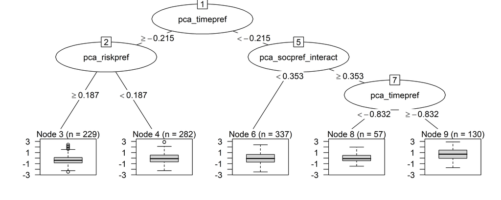

Mivel jóval kevesebb változó van, kevésbé tudja szétszedni a jókat.

# Random forest - read

“read változóra megcsinálom az előző elemezést:

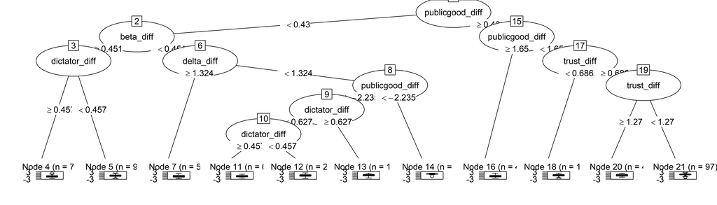

Összehasonlítás a nyers változókkal:

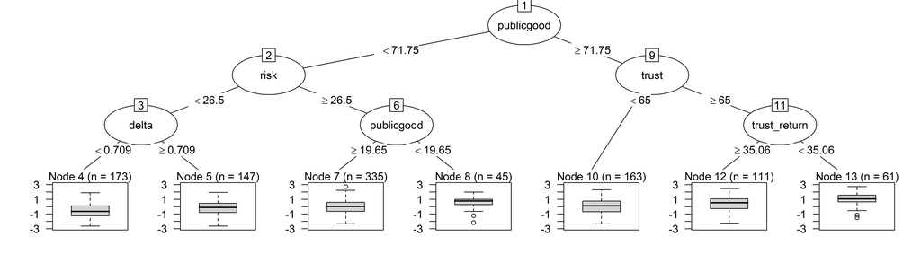

#### Az összehasonlítás eredménye readre

A demeanelt verzió sokkal jobban szétszedi a “klasztereket”, csakúgy, mint a math esetében.

Legjobb teljesítményűek (azaz ahol a klaszterek átlaga 1 körül van):

### Sima lineáris regresszió - PCA-kkal

Nagyon érdekes: a matekkal ellentétben itt a socpref_nointeract ami dominál (dictator game)

```
##
## Call:
## lm(formula = read ~ pca_socpref_interact + pca_timepref + pca_socpref_nointeract +
##     pca_riskpref + comp + age + math, data = data_analysis_clean)
##
## Residuals:
##      Min       1Q   Median       3Q      Max
## -2.19383 -0.45420  0.03409  0.44094  2.20183
##
## Coefficients:
##                         Estimate Std. Error t value Pr(>|t|)
## (Intercept)             0.315470   0.313688   1.006   0.3148
## pca_socpref_interact    0.009281   0.020736   0.448   0.6546
## pca_timepref            0.018974   0.020798   0.912   0.3618
## pca_socpref_nointeract  0.036207   0.020940   1.729   0.0841 .
## pca_riskpref            0.022222   0.020808   1.068   0.2858
## comp                   -0.033865   0.043126  -0.785   0.4325
## age                    -0.001433   0.001550  -0.924   0.3556
## math                    0.745653   0.021169  35.224   <2e-16 ***
## ---
## Signif. codes:  0 '***' 0.001 '**' 0.01 '*' 0.05 '.' 0.1 ' ' 1
##
## Residual standard error: 0.6648 on 1027 degrees of freedom
## Multiple R-squared:  0.5627, Adjusted R-squared:  0.5597
## F-statistic: 188.8 on 7 and 1027 DF,  p-value: < 2.2e-16
```

diff adatokra illesztve:

```
##
## Call:
## lm(formula = read ~ delta_diff + beta_diff + dictator_diff +
##     dictator_schoolmate_diff + risk_diff + publicgood_diff +
##     trust_diff + trust_return_diff + age, data = data_analysis_clean)
##
## Residuals:
##      Min       1Q   Median       3Q      Max
## -2.65461 -0.71499  0.03552  0.71452  2.56255
##
## Coefficients:
##                           Estimate Std. Error t value Pr(>|t|)
## (Intercept)               2.080454   0.460155   4.521 6.87e-06 ***
## delta_diff                0.012901   0.034453   0.374   0.7081
## beta_diff                -0.035734   0.034166  -1.046   0.2959
## dictator_diff             0.053353   0.036856   1.448   0.1480
## dictator_schoolmate_diff -0.055511   0.036565  -1.518   0.1293
## risk_diff                 0.071250   0.032525   2.191   0.0287 *
## publicgood_diff           0.048508   0.034107   1.422   0.1553
## trust_diff                0.041205   0.036642   1.125   0.2611
## trust_return_diff        -0.012157   0.034251  -0.355   0.7227
## age                      -0.010268   0.002271  -4.521 6.87e-06 ***
## ---
## Signif. codes:  0 '***' 0.001 '**' 0.01 '*' 0.05 '.' 0.1 ' ' 1
##
## Residual standard error: 0.9882 on 1025 degrees of freedom
## Multiple R-squared:  0.03572,    Adjusted R-squared:  0.02725
## F-statistic: 4.218 on 9 and 1025 DF,  p-value: 2.227e-05
```

```
##
## Call:
## lm(formula = read ~ delta + beta + dictator + dictator_schoolmate +
##     risk + publicgood + trust + trust_return + age, data = data)
##
## Residuals:
##      Min       1Q   Median       3Q      Max
## -2.64344 -0.65503  0.03691  0.65707  2.55191
##
## Coefficients:
##                      Estimate Std. Error t value Pr(>|t|)
## (Intercept)          1.081746   0.519484   2.082 0.037558 *
## delta                0.877683   0.210185   4.176 3.22e-05 ***
## beta                -0.012612   0.143264  -0.088 0.929865
## dictator            -0.002144   0.001932  -1.110 0.267212
## dictator_schoolmate -0.002846   0.001688  -1.686 0.092070 .
## risk                 0.009713   0.001674   5.803 8.68e-09 ***
## publicgood           0.003117   0.001187   2.625 0.008782 **
## trust                0.005437   0.001396   3.895 0.000104 ***
## trust_return        -0.003783   0.001991  -1.900 0.057675 .
## age                 -0.011009   0.002157  -5.103 3.98e-07 ***
## ---
## Signif. codes:  0 '***' 0.001 '**' 0.01 '*' 0.05 '.' 0.1 ' ' 1
##
## Residual standard error: 0.9341 on 1025 degrees of freedom
##   (73 observations deleted due to missingness)
## Multiple R-squared:  0.1384, Adjusted R-squared:  0.1308
## F-statistic: 18.29 on 9 and 1025 DF,  p-value: < 2.2e-16
```

# Clustering - demeanelt adatokra

(Mindegyik esetben 5 klaszternél húztam meg a határt. )

For the hierarchical clusters, in order to get this amount of clusters, we chose a cut-off value of 8.1.

Complete clustering:

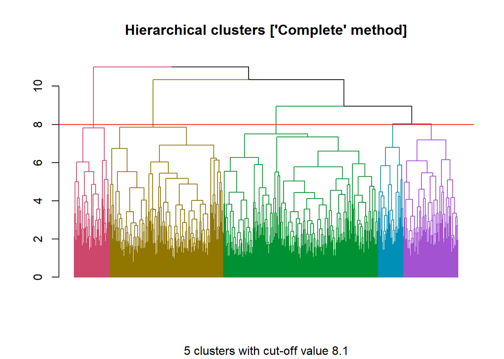

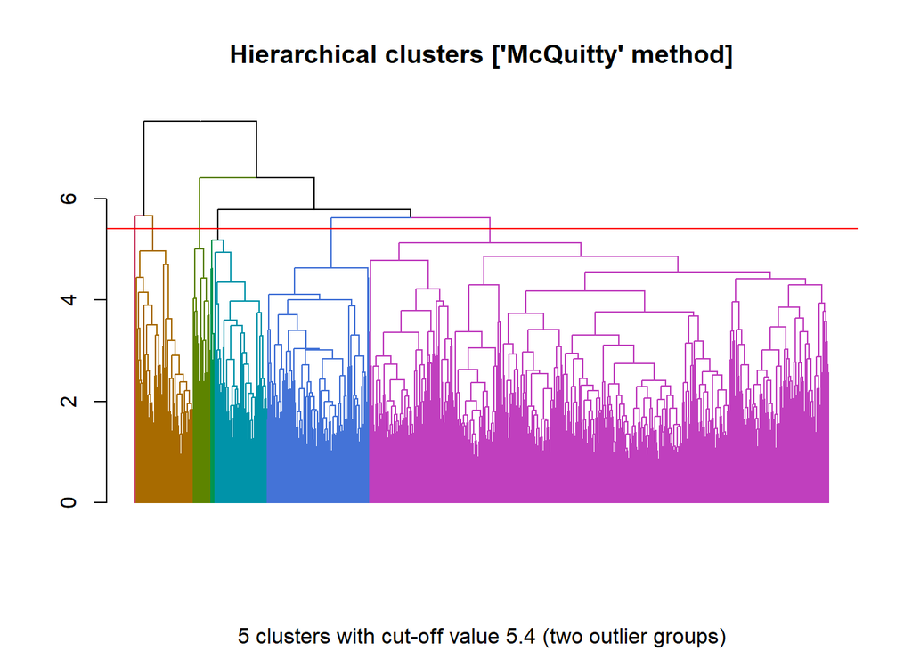

K-means clustering:

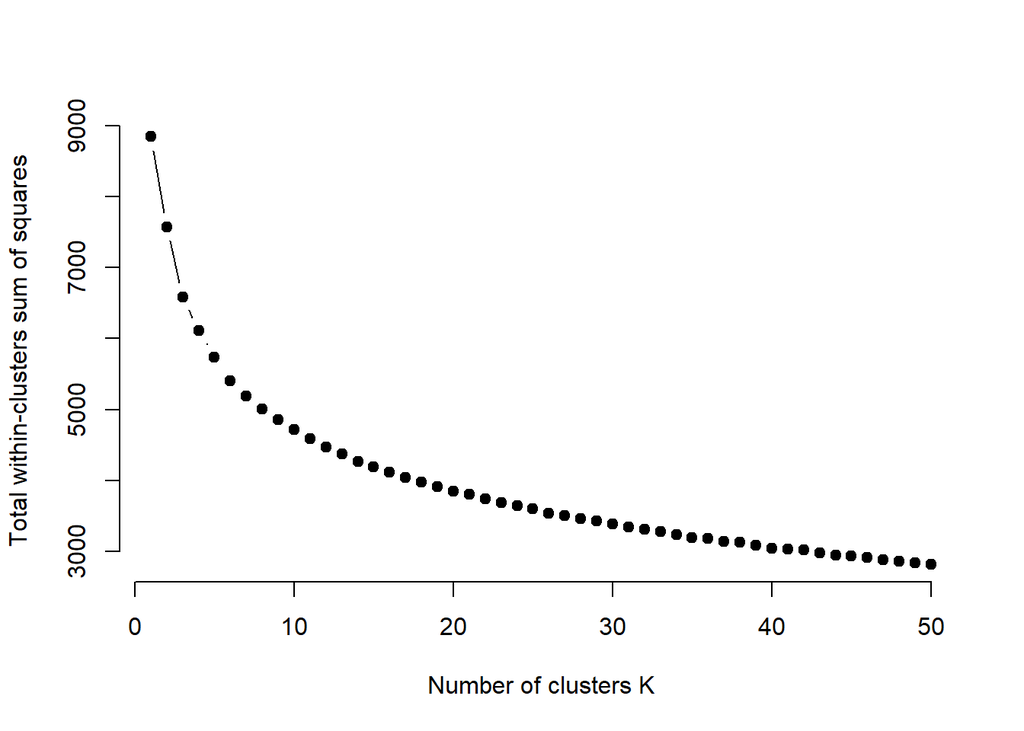

Now knowing that the number of factors is the same, I run the K-means clustering algorithm for 5 clusters:

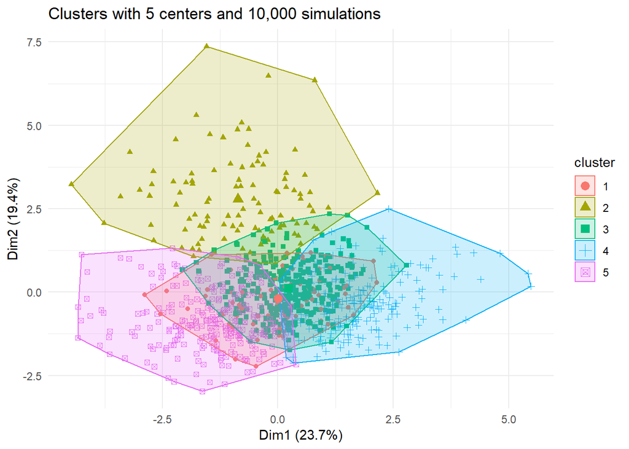

### k-medoid (PAM):

```
##           Length Class  Mode
## pamobject 10     pam    list
## nc         1     -none- numeric
## crit      10     -none- numeric
```

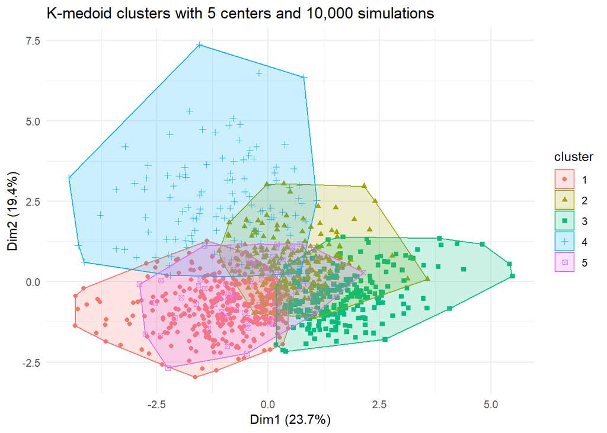

#MCLUST clustering : (model based clustering)

(for more on that: https://cran.r-project.org/web/packages/mclust/vignettes/mclust.html)

```
## Package 'mclust' version 5.4.9
```

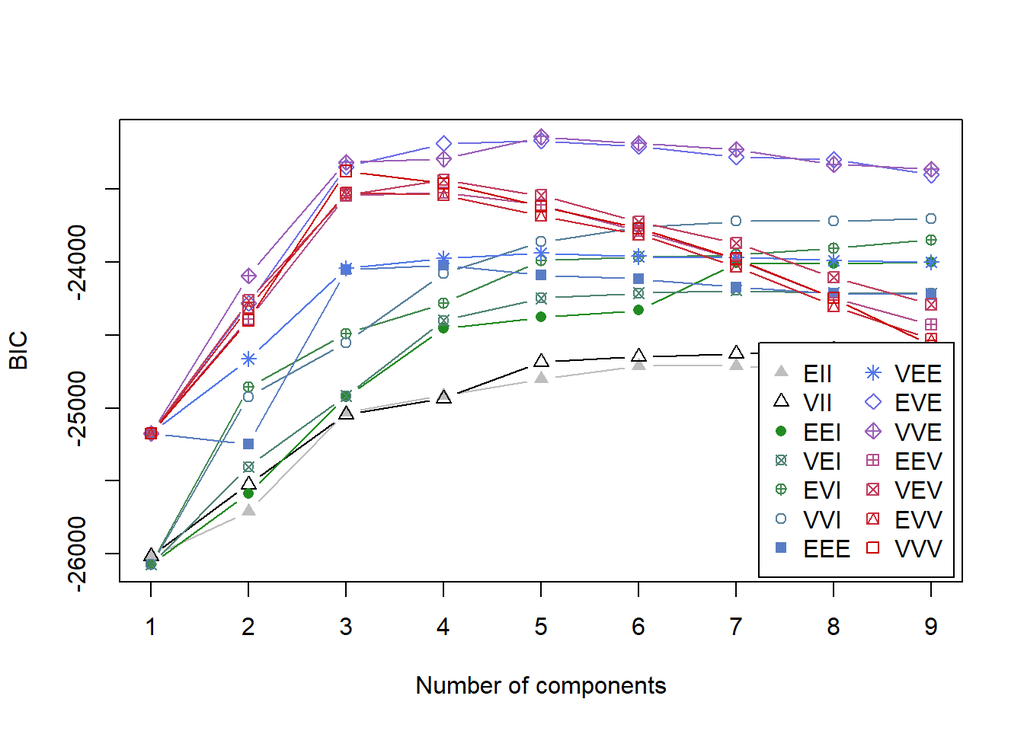

```
## ----------------------------------------------------
## Gaussian finite mixture model fitted by EM algorithm
## ----------------------------------------------------
##
## Mclust VVE (ellipsoidal, equal orientation) model with 5 components:
##
##  log-likelihood    n  df       BIC      ICL
##       -11119.65 1035 130 -23141.79 -23612.8
##
## Clustering table:
##   1   2   3   4   5
## 111 269 257 257 141
##
## Mixing probabilities:
##         1         2         3         4         5
## 0.1186690 0.2630608 0.2415979 0.2301264 0.1465459
##
## Means:
##                                 [,1]        [,2]        [,3]        [,4]
## delta_diff               -1.05829526 -0.40972183  0.87042803  0.09830419
## beta_diff                 1.49243918  0.49238960 -0.20032508 -0.33863172
## beta_0_diff               1.45346200 -0.06862355 -0.70553234 -0.48038795
## dictator_diff             0.20981135 -0.13000351 -0.07836038  0.16336212
## dictator_schoolmate_diff  0.11625118 -0.09302430 -0.15663184  0.20463103
## risk_diff                -0.20159015 -0.12501671  0.23094181 -0.14181568
## publicgood_diff          -0.05053291 -0.04984438  0.18303558 -0.09110797
## trust_diff               -0.07503449 -0.11539313  0.25705832 -0.10177446
## trust_return_diff        -0.08243442 -0.04758145  0.04245236  0.03953326
##                                 [,5]
## delta_diff                0.09504942
## beta_diff                -1.29070059
## beta_0_diff               0.85861614
## dictator_diff            -0.07182173
## dictator_schoolmate_diff -0.03583414
## risk_diff                 0.22657331
## publicgood_diff          -0.02746850
## trust_diff                0.02355628
## trust_return_diff        -0.06134145
##
## Variances:
```

[output cut: 140 more lines]

```
## dictator_schoolmate_diff              1.068381215 -0.099964590     0.056731271
## risk_diff                            -0.099964590  1.143573107     0.156296831
## publicgood_diff                       0.056731271  0.156296831     0.995740348
## trust_diff                            0.208907625  0.191698968     0.333162065
## trust_return_diff                     0.178442486 -0.018470127     0.235377195
##                          trust_diff trust_return_diff
## delta_diff               0.04437604       0.005898441
## beta_diff                0.01632886      -0.001019915
## beta_0_diff              0.01383500      -0.003212685
## dictator_diff            0.19908739       0.199238519
## dictator_schoolmate_diff 0.20890762       0.178442486
## risk_diff                0.19169897      -0.018470127
## publicgood_diff          0.33316206       0.235377195
## trust_diff               0.97517354       0.251670337
## trust_return_diff        0.25167034       0.917655837
```

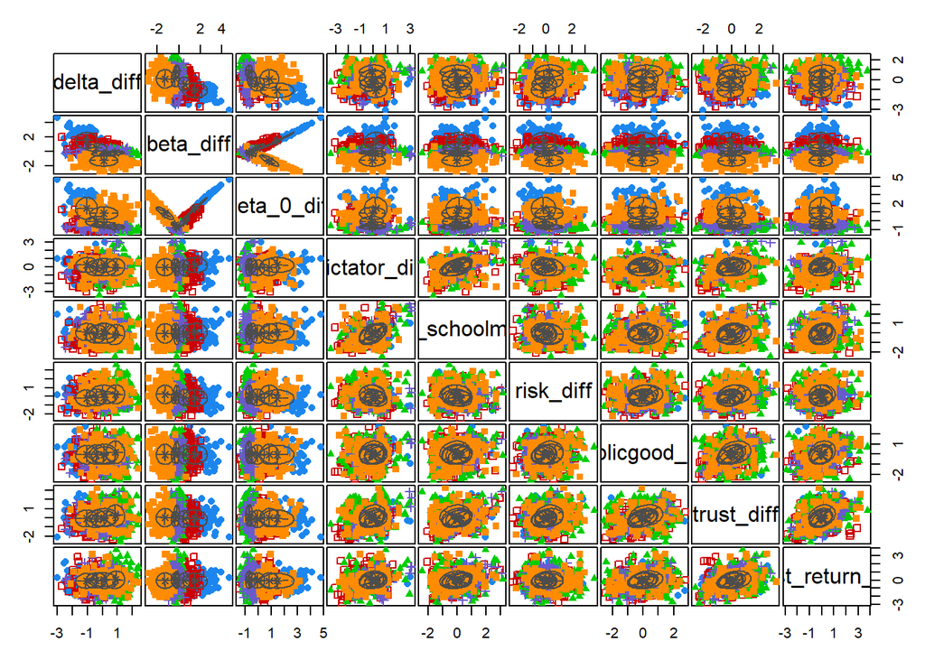

#### Cross-table of various observations using the two clustering algorithms:

##### Complete Hierarchical vs K-means:

Hierarchical clusters (row) vs. k-means cluster (columns)

|  | 1 | 2 | 3 | 4 | 5 |
| --- | --- | --- | --- | --- | --- |
| 1 | 0 | 82 | 5 | 0 | 10 |
| 2 | 11 | 17 | 144 | 125 | 120 |
| 3 | 7 | 8 | 166 | 105 | 19 |
| 4 | 5 | 1 | 11 | 10 | 120 |
| 5 | 63 | 0 | 3 | 1 | 2 |

##### Complete Hierarchical vs McQuitty Hierarchical:

| 1 | 2 | 3 | 4 | 5 |
| --- | --- | --- | --- | --- |
| 8 | 25 | 61 | 3 | 0 |
| 48 | 359 | 4 | 0 | 6 |
| 27 | 225 | 18 | 25 | 10 |
| 67 | 76 | 2 | 0 | 2 |
| 2 | 0 | 0 | 1 | 66 |

##### McQuitty Hierarchical vs K-means:

Hierarchical clusters [McQuitty] (row) vs. k-means cluster (columns)

|  | 1 | 2 | 3 | 4 | 5 |
| --- | --- | --- | --- | --- | --- |
| 1 | 7 | 5 | 60 | 0 | 80 |
| 2 | 9 | 32 | 241 | 218 | 185 |
| 3 | 0 | 68 | 14 | 1 | 2 |
| 4 | 1 | 3 | 8 | 17 | 0 |
| 5 | 69 | 0 | 6 | 5 | 4 |

Összehasonlítás summary:

(k-mean cluster szempontjából) az 1-es és 2-es klaszterek nagyon hasonló, a többiben szórnak a klaszterezési metódusok.

Ezek kevesebb megfigyeléssel rendelkeznek, mint a többi, jobban el is válnak. Ezeket így külön meg is nézem

# Clusters 1 and 2

|  | 1 (N=86) | 2 (N=108) | 3 (N=329) | 4 (N=241) | 5 (N=271) | Total (N=1035) | p value |
| --- | --- | --- | --- | --- | --- | --- | --- |
| **delta** |  |  |  |  |  |  | < 0.001 |
| &nbsp;&nbsp;&nbsp;Mean (SD) | 0.761 (0.146) | 0.562 (0.083) | 0.740 (0.138) | 0.815 (0.139) | 0.761 (0.146) | 0.746 (0.153) |  |
| &nbsp;&nbsp;&nbsp;Range | 0.465 - 0.971 | 0.333 - 0.758 | 0.333 - 0.971 | 0.333 - 0.971 | 0.333 - 0.971 | 0.333 - 0.971 |  |
| **beta** |  |  |  |  |  |  | < 0.001 |
| &nbsp;&nbsp;&nbsp;Mean (SD) | 0.678 (0.133) | 1.457 (0.265) | 1.032 (0.104) | 0.990 (0.111) | 1.007 (0.127) | 1.031 (0.222) |  |
| &nbsp;&nbsp;&nbsp;Range | 0.343 - 0.951 | 1.083 - 2.913 | 0.661 - 1.411 | 0.527 - 1.311 | 0.534 - 1.388 | 0.343 - 2.913 |  |
| **dictator** |  |  |  |  |  |  | < 0.001 |
| &nbsp;&nbsp;&nbsp;Mean (SD) | 41.063 (15.311) | 42.837 (15.528) | 47.519 (8.836) | 46.745 (16.337) | 20.175 (16.175) | 39.154 (18.196) |  |
| &nbsp;&nbsp;&nbsp;Range | 0.000 - 75.000 | 0.000 - 75.000 | 0.000 - 100.000 | 0.000 - 100.000 | 0.000 - 50.000 | 0.000 - 100.000 |  |
| **dictator_schoolmate** |  |  |  |  |  |  | < 0.001 |
| &nbsp;&nbsp;&nbsp;Mean (SD) | 29.680 (18.265) | 30.921 (19.870) | 33.288 (16.994) | 34.240 (22.701) | 12.125 (13.025) | 27.422 (20.215) |  |
| &nbsp;&nbsp;&nbsp;Range | 0.000 - 100.000 | 0.000 - 100.000 | 0.000 - 100.000 | 0.000 - 100.000 | 0.000 - 50.000 | 0.000 - 100.000 |  |
| **risk** |  |  |  |  |  |  | < 0.001 |
| &nbsp;&nbsp;&nbsp;Mean (SD) | 33.523 (17.491) | 29.630 (18.386) | 26.240 (14.026) | 44.481 (19.905) | 34.649 (17.495) | 33.648 (18.471) |  |
| &nbsp;&nbsp;&nbsp;Range | 1.000 - 93.000 | 1.000 - 90.000 | 1.000 - 66.000 | 1.000 - 99.000 | 1.000 - 99.000 | 1.000 - 99.000 |  |
| **publicgood** |  |  |  |  |  |  | < 0.001 |
| &nbsp;&nbsp;&nbsp;Mean (SD) | 57.483 (28.112) | 58.707 (22.884) | 53.241 (22.199) | 84.056 (19.494) | 50.171 (29.273) | 60.535 (27.615) |  |
| &nbsp;&nbsp;&nbsp;Range | 0.000 - 100.000 | 0.000 - 100.000 | 0.000 - 100.000 | 35.000 - 100.000 | 0.000 - 100.000 | 0.000 - 100.000 |  |
| **trust** |  |  |  |  |  |  | < 0.001 |
| &nbsp;&nbsp;&nbsp;Mean (SD) | 54.302 (22.624) | 52.130 (22.005) | 54.559 (18.819) | 76.929 (22.035) | 38.266 (22.118) | 55.227 (25.127) |  |
| &nbsp;&nbsp;&nbsp;Range | 10.000 - 100.000 | 0.000 - 100.000 | 10.000 - 100.000 | 30.000 - 100.000 | 0.000 - 100.000 | 0.000 - 100.000 |  |
| **trust_return** |  |  |  |  |  |  | < 0.001 |
| &nbsp;&nbsp;&nbsp;Mean (SD) | 38.153 (12.380) | 39.006 (13.739) | 38.004 (11.586) | 48.513 (16.747) | 30.184 (16.441) | 38.520 (15.874) |  |
| &nbsp;&nbsp;&nbsp;Range | 3.333 - 66.667 | 13.587 - 95.450 | 10.657 - 84.563 | 5.000 - 100.000 | 0.000 - 82.788 | 0.000 - 100.000 |  |
| **comp** |  |  |  |  |  |  | 0.209 |
| &nbsp;&nbsp;&nbsp;Mean (SD) | 0.698 (0.462) | 0.593 (0.494) | 0.574 (0.495) | 0.639 (0.481) | 0.631 (0.483) | 0.616 (0.486) |  |
| &nbsp;&nbsp;&nbsp;Range | 0.000 - 1.000 | 0.000 - 1.000 | 0.000 - 1.000 | 0.000 - 1.000 | 0.000 - 1.000 | 0.000 - 1.000 |  |
| **pca_socpref_interact** |  |  |  |  |  |  | < 0.001 |
| &nbsp;&nbsp;&nbsp;Mean (SD) | -0.467 (0.820) | -0.030 (0.759) | -0.201 (0.652) | 1.038 (0.736) | -0.538 (1.014) | -0.005 (1.001) |  |
| &nbsp;&nbsp;&nbsp;Range | -2.296 - 1.133 | -1.812 - 1.588 | -2.418 - 1.492 | -0.848 - 3.153 | -3.043 - 2.038 | -3.043 - 3.153 |  |
| **pca_timepref** |  |  |  |  |  |  | < 0.001 |
| &nbsp;&nbsp;&nbsp;Mean (SD) | -0.164 (0.470) | 2.232 (0.920) | -0.189 (0.567) | -0.452 (0.593) | -0.246 (0.652) | -0.010 (0.999) |  |
| &nbsp;&nbsp;&nbsp;Range | -1.323 - 0.945 | 1.034 - 5.638 | -1.728 - 1.163 | -1.702 - 1.421 | -1.734 - 1.570 | -1.734 - 5.638 |  |
| **pca_socpref_nointeract** |  |  |  |  |  |  | < 0.001 |
| &nbsp;&nbsp;&nbsp;Mean (SD) | 0.436 (0.953) | -0.046 (0.919) | -0.448 (0.777) | 0.528 (1.050) | -0.030 (0.969) | 0.004 (1.000) |  |
| &nbsp;&nbsp;&nbsp;Range | -1.675 - 3.175 | -2.096 - 2.317 | -2.547 - 2.207 | -2.057 - 3.446 | -2.342 - 2.960 | -2.547 - 3.446 |  |
| **pca_riskpref** |  |  |  |  |  |  | < 0.001 |
| &nbsp;&nbsp;&nbsp;Mean (SD) | 0.345 (0.813) | 0.207 (0.901) | 0.492 (0.607) | 0.303 (0.935) | -1.070 (0.679) | -0.003 (0.996) |  |
| &nbsp;&nbsp;&nbsp;Range | -1.400 - 3.163 | -2.358 - 2.443 | -1.062 - 2.562 | -2.171 - 3.476 | -3.071 - 0.784 | -3.071 - 3.476 |  |
| **math** |  |  |  |  |  |  | 0.008 |
| &nbsp;&nbsp;&nbsp;Mean (SD) | -0.060 (0.989) | -0.199 (1.036) | -0.068 (0.984) | 0.174 (0.998) | 0.031 (0.991) | 0.001 (1.000) |  |
| &nbsp;&nbsp;&nbsp;Range | -1.945 - 2.273 | -2.459 - 2.880 | -2.490 - 2.695 | -2.061 - 2.903 | -2.291 - 2.408 | -2.490 - 2.903 |  |
| **read** |  |  |  |  |  |  | 0.490 |
| &nbsp;&nbsp;&nbsp;Mean (SD) | 0.009 (1.046) | -0.128 (0.969) | 0.017 (1.002) | 0.078 (1.006) | -0.021 (0.999) | 0.006 (1.002) |  |
| &nbsp;&nbsp;&nbsp;Range | -2.322 - 1.848 | -2.342 - 2.471 | -2.408 - 2.730 | -2.633 - 2.197 | -2.643 - 2.730 | -2.643 - 2.730 |  |

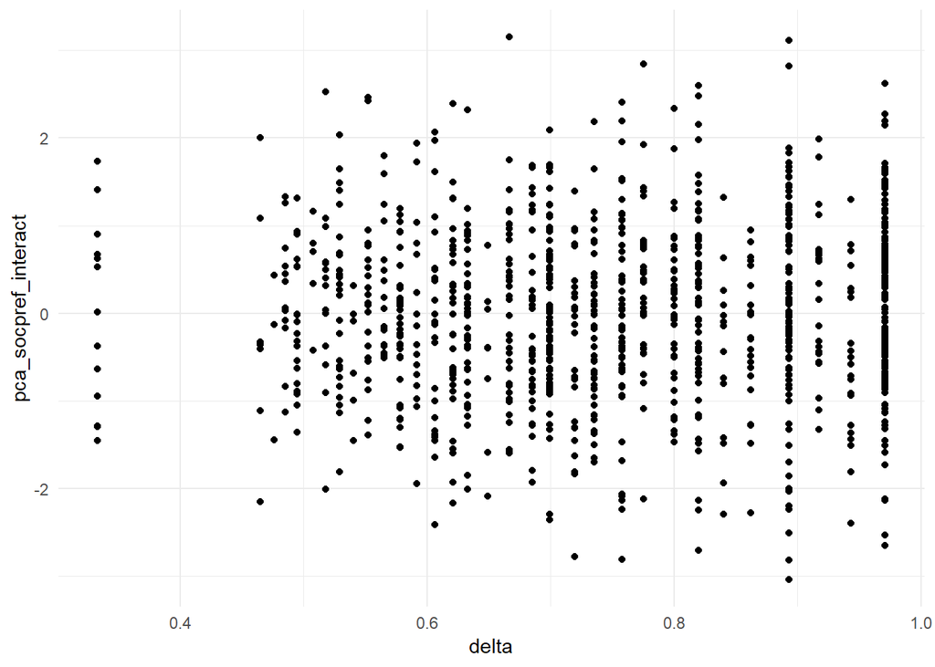

```
##
## Call:
## lm(formula = kmeans_cluster ~ as.factor(schoolid), data = data_analysis_clean_describe)
##
## Residuals:
##     Min      1Q  Median      3Q     Max
## -2.5860 -0.5544 -0.3220  1.4140  1.6780
##
## Coefficients:
##                        Estimate Std. Error t value Pr(>|t|)
## (Intercept)           3.4393939  0.1501588  22.905   <2e-16 ***
## as.factor(schoolid)2  0.1013786  0.1701016   0.596    0.551
## as.factor(schoolid)3  0.1465933  0.1789590   0.819    0.413
## as.factor(schoolid)4 -0.1173600  0.2185646  -0.537    0.591
## as.factor(schoolid)5 -0.0050505  0.1938542  -0.026    0.979
## as.factor(schoolid)6 -0.0268065  0.1815332  -0.148    0.883
## as.factor(schoolid)7  0.0001665  0.1972332   0.001    0.999
## as.factor(schoolid)8  0.0237640  0.1954799   0.122    0.903
## as.factor(schoolid)9  0.1149539  0.1967821   0.584    0.559
## ---
## Signif. codes:  0 '***' 0.001 '**' 0.01 '*' 0.05 '.' 0.1 ' ' 1
##
## Residual standard error: 1.22 on 1026 degrees of freedom
## Multiple R-squared:  0.003725,   Adjusted R-squared:  -0.004043
## F-statistic: 0.4795 on 8 and 1026 DF,  p-value: 0.8713
```